# Assignment 3

DATA 311

Author

Noah Semashkewich - 53882783

# Assignment 3

## Exploratory Data Analysis

### Exercise 1)

```r
datasalaries = read.csv("datasalaries.csv")

datasalaries = na.omit(datasalaries)
datasalaries$company = as.factor(datasalaries$company)
datasalaries$gender = as.factor(datasalaries$gender)
datasalaries$Race = as.factor(datasalaries$Race)
datasalaries$Education = as.factor(datasalaries$Education)

str(datasalaries)
```

```
'data.frame':   7517 obs. of  7 variables:
 $ company          : Factor w/ 6 levels "Amazon","Apple",..: 4 5 4 5 1 1 2 1 1 3 ...
 $ salary           : int  400000 136000 337000 222000 310000 620000 180000 210000 142000 242000 ...
 $ yearsofexperience: int  5 3 6 4 15 19 1 4 0 2 ...
 $ yearsatcompany   : int  5 2 6 4 3 7 1 1 0 2 ...
 $ gender           : Factor w/ 3 levels "Female","Male",..: 2 2 2 2 2 2 2 2 2 2 ...
 $ Race             : Factor w/ 5 levels "Asian","Black",..: 1 4 1 1 1 1 1 3 1 5 ...
 $ Education        : Factor w/ 5 levels "Bachelor's Degree",..: 4 1 1 3 1 1 1 2 3 3 ...
```

### Exercise 2)

```r
set.seed(5388278)

sampleSize = floor(0.5 * nrow(datasalaries))
set = sample(seq_len(nrow(datasalaries)), size = sampleSize)
train_set = datasalaries[set, ]
test_set = datasalaries[-set, ]

dim(train_set)
```

```
[1] 3758    7
```

```r
dim(test_set)
```

```
[1] 3759    7
```

## Decision Trees

### Exercise 3)

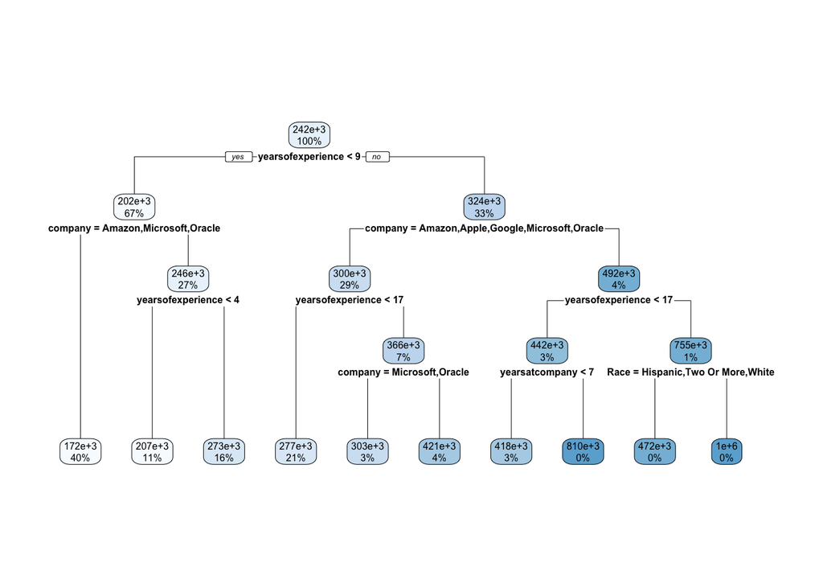

```r
library(rpart)
library(rpart.plot)
decision_tree = rpart(salary ~ ., data = train_set, method = "anova")

rpart.plot(decision_tree)
```

### Exercise 4)

```r
tree_prediction = predict(decision_tree, newdata = test_set)

# Calculate residuals
residuals = tree_prediction - test_set$salary

# Calculate RMSE
rmse = sqrt(mean(residuals^2))
print(rmse)
```

```
[1] 130630.2
```

## Random Forests

### Exercise 5)

```r
library(randomForest)
set.seed(51940633)

randomForestModel = randomForest(salary ~ ., data = train_set, ntree = 500, importance = TRUE)

print(randomForestModel)
```

```
Call:
 randomForest(formula = salary ~ ., data = train_set, ntree = 500,      importance = TRUE)
               Type of random forest: regression
                     Number of trees: 500
No. of variables tried at each split: 2

          Mean of squared residuals: 17403615266
                    % Var explained: 30.2
```

```r
importance(randomForestModel)
```

```
                     %IncMSE IncNodePurity
company           30.9717305  1.402014e+13
yearsofexperience 24.5248248  2.562575e+13
yearsatcompany    13.1645813  1.126121e+13
gender             3.5023418  1.773392e+12
Race               0.9356034  4.326253e+12
Education          2.5481032  4.450245e+12
```

### Exercise 6)

```r
randomForest_pred = predict(randomForestModel, newdata = test_set)

randomForest_rmse = sqrt(mean((test_set$salary - randomForest_pred)^2))

randomForest_mse = mean(randomForestModel$mse)
randomForest_oob_rmse = sqrt(randomForest_mse)

print(paste("Test RMSE:", randomForest_rmse))
```

```
[1] "Test RMSE: 120697.613059604"
```

```r
print(paste("OOB RMSE:", randomForest_oob_rmse))
```

```
[1] "OOB RMSE: 132088.962064221"
```

The test RMSE **(120,697.61)** is slightly lower than the OOB RMSE **(132,088.96**), suggesting that the model generalizes well to the test set. This indicates that the model is not overfitting and performs reasonably well on unseen data. The small difference shows the model’s robustness and its ability to capture underlying patterns without being overly tuned to the training data.

### Exercise 7)

```r
variable_importance = importance(randomForestModel)

print(variable_importance)
```

```
                     %IncMSE IncNodePurity
company           30.9717305  1.402014e+13
yearsofexperience 24.5248248  2.562575e+13
yearsatcompany    13.1645813  1.126121e+13
gender             3.5023418  1.773392e+12
Race               0.9356034  4.326253e+12
Education          2.5481032  4.450245e+12
```

Based on the variance importance measures from the random forest model, the most important feature for prediction is **company**, with the highest **%IncMSE** (30.97) and a significant **IncNodePurity** value (1.40 × 10^13). This suggests that “company” has the greatest influence on the model’s predictions.

### Exercise 8)

```r
set.seed(53882783*2)
randomForestBagging = randomForest(salary ~ ., data = train_set, ntree = 500, mtry = ncol(train_set) - 1, importance = TRUE)

print(randomForestBagging)
```

```
Call:
 randomForest(formula = salary ~ ., data = train_set, ntree = 500,      mtry = ncol(train_set) - 1, importance = TRUE)
               Type of random forest: regression
                     Number of trees: 500
No. of variables tried at each split: 6

          Mean of squared residuals: 20004233386
                    % Var explained: 19.77
```

### Exercise 9)

```r
randomForestBagging_pred = predict(randomForestBagging, newdata = test_set)
test_rmse = sqrt(mean((test_set$salary - randomForestBagging_pred)^2))

oob_mse = mean(randomForestBagging$mse)
oob_rmse = sqrt(oob_mse)

print(paste("Test RMSE:", test_rmse))
```

```
[1] "Test RMSE: 128280.732339567"
```

```r
print(paste("OOB RMSE:", oob_rmse))
```

```
[1] "OOB RMSE: 142244.953878373"
```

The test RMSE is **128,280.73**, while the OOB RMSE is **142,244.95**. This shows that the random forest model performs better on the test data than on the OOB data, indicating that it generalizes fairly well to new, unseen data. The lower test RMSE suggests the model is making more accurate predictions when evaluated on the test set compared to the OOB estimate.

### Exercise 10)

```r
importance(randomForestBagging)
```

```
                    %IncMSE IncNodePurity
company           25.687697  1.387769e+13
yearsofexperience 24.256197  3.227560e+13
yearsatcompany     7.031108  1.303985e+13
gender             3.714046  2.052484e+12
Race               5.694264  6.127003e+12
Education          4.192257  7.676121e+12
```

Based on the importance values from the bagging model, the most important feature for predicting salary is **yearsofexperience**. This is determined by the higher value in the IncNodePurity column, which indicates the total decrease in node impurity when the feature is used to split data. In this case, “yearsofexperience” has the highest value in terms of **IncNodePurity (3.227560e+13)** compared to other features.

## Regularization

### Exercise 11)

```r
train_predMatrix = model.matrix(salary ~ ., data = train_set)[, -1]
test_predMatrix = model.matrix(salary ~ ., data = test_set)[, -1]

head(train_predMatrix)
```

```
     companyApple companyFacebook companyGoogle companyMicrosoft companyOracle
729             0               0             0                0             0
7316            0               0             1                0             0
2256            0               0             0                0             0
4675            0               0             0                0             0
4074            0               0             0                0             0
7459            0               0             0                0             0
     yearsofexperience yearsatcompany genderMale genderOther RaceBlack
729                 20              8          1           0         0
7316                 0              0          1           0         0
2256                 9              3          0           0         0
4675                 2              2          0           0         0
4074                19              1          1           0         0
7459                14              8          0           0         0
     RaceHispanic RaceTwo Or More RaceWhite EducationHighschool
729             0               0         1                   0
7316            0               1         0                   0
2256            0               0         1                   0
4675            0               0         0                   0
4074            0               0         1                   0
7459            0               0         0                   0
     EducationMaster's Degree EducationPhD EducationSome College
729                         0            0                     0
7316                        0            0                     0
2256                        0            0                     0
4675                        1            0                     0
4074                        1            0                     0
7459                        1            0                     0
```

```r
head(test_predMatrix)
```

```
   companyApple companyFacebook companyGoogle companyMicrosoft companyOracle
1             0               0             1                0             0
4             0               0             0                1             0
8             0               0             0                0             0
11            0               0             0                1             0
12            0               0             0                1             0
14            0               1             0                0             0
   yearsofexperience yearsatcompany genderMale genderOther RaceBlack
1                  5              5          1           0         0
4                  4              4          1           0         0
8                  4              1          1           0         0
11                 1              0          0           0         0
12                10              2          1           0         0
14                14              2          1           0         0
   RaceHispanic RaceTwo Or More RaceWhite EducationHighschool
1             0               0         0                   0
4             0               0         0                   0
8             1               0         0                   1
11            1               0         0                   0
12            0               0         0                   0
14            0               1         0                   0
   EducationMaster's Degree EducationPhD EducationSome College
1                         0            1                     0
4                         1            0                     0
8                         0            0                     0
11                        0            0                     0
12                        0            0                     0
14                        1            0                     0
```

### Exercise 12)

```r
library(glmnet)
y = train_set$salary

ridge = glmnet(train_predMatrix, y, alpha = 0)

print(ridge)
```

```
Call:  glmnet(x = train_predMatrix, y = y, alpha = 0)

    Df  %Dev   Lambda
1   17  0.00 65960000
2   17  0.19 60100000
3   17  0.21 54760000
4   17  0.23 49900000
5   17  0.26 45470000
6   17  0.28 41430000
7   17  0.31 37750000
8   17  0.34 34390000
9   17  0.37 31340000
10  17  0.41 28550000
11  17  0.44 26020000
12  17  0.49 23710000
```

[output cut: 88 more lines]

### Exercise 13)

```r
library(glmnet)

set.seed(53882783)

cv_model = cv.glmnet(x = train_predMatrix, y = y, alpha = 0)

best_lambda = cv_model$lambda.min

cat("Best lambda (lowest CV estimate of error):", best_lambda, "\n")
```

```
Best lambda (lowest CV estimate of error): 6596.378
```

### Exercise 14)

```r
ridge_best = glmnet(train_predMatrix, y, alpha = 0, lambda = best_lambda)

ridge_pred = predict(ridge_best, newx = test_predMatrix)

ridge_test_res = ridge_pred - test_set$salary
ridge_test_rmse = sqrt(mean(ridge_test_res^2))
print(paste("Test RMSE for Ridge regression:", ridge_test_rmse))
```

```
[1] "Test RMSE for Ridge regression: 122271.346032393"
```

The test RMSE for the Ridge regression model using the best lambda (λ= 6596.378) is 122,271.35. This represents the model’s accuracy in predicting salaries on the test set, with the selected lambda minimizing the cross-validated error in Exercise 13. This suggests that the ridge model balances bias and variance well.

### Exercise 15)

```r
lambda_1se = cv_model$lambda.1se
ridge_1se = glmnet(train_predMatrix, y, alpha = 0, lambda = lambda_1se)

ridge_1se_pred = predict(ridge_1se, newx = test_predMatrix)

ridge_1se_test_res = ridge_1se_pred - test_set$salary
ridge_1se_test_rmse = sqrt(mean(ridge_1se_test_res^2))

print(paste("Lambda within 1 SE of the minimum:", lambda_1se))
```

```
[1] "Lambda within 1 SE of the minimum: 1207624.2551761"
```

```r
print(paste("Test RMSE for Ridge regression with lambda.1se:", ridge_1se_test_rmse))
```

```
[1] "Test RMSE for Ridge regression with lambda.1se: 142801.89424337"
```

### Exercise 16)

```r
library(glmnet)

lasso_model = glmnet(train_predMatrix, y, alpha = 1)
print(lasso_model)
```

```
Call:  glmnet(x = train_predMatrix, y = y, alpha = 1)

   Df  %Dev Lambda
1   0  0.00  65960
2   1  2.96  60100
3   1  5.42  54760
4   1  7.46  49900
5   1  9.16  45470
6   1 10.57  41430
7   2 12.40  37750
8   2 14.40  34390
9   2 16.05  31340
10  2 17.43  28550
11  2 18.57  26020
12  2 19.52  23710
```

[output cut: 54 more lines]

### Exercise 17)

```r
library(glmnet)

set.seed(53882783)

lasso_cv_model = cv.glmnet(x = train_predMatrix, y, alpha = 0)

lasso_best_lambda = lasso_cv_model$lambda.min

print(paste("Best lambda (lowest CV estimate of error):", lasso_best_lambda))
```

```
[1] "Best lambda (lowest CV estimate of error): 6596.37845657146"
```

### Exercise 18)

```r
lasso_best_model = glmnet(x = train_predMatrix, y = y, alpha = 1, lambda = lasso_cv_model$lambda.min)

test_pred = predict(lasso_best_model, s = lasso_best_lambda, newx = test_predMatrix)

test_y = test_set$salary

test_rmse = sqrt(mean((test_pred - test_y)^2))

print(paste("Test RMSE for LASSO model with best lambda:", test_rmse))
```

```
[1] "Test RMSE for LASSO model with best lambda: 123938.081782318"
```

### Exercise 19)

```r
lasso_best_lambda_1se = lasso_cv_model$lambda.1se
print(paste("Best lambda within 1 SE of minimum:", lasso_best_lambda_1se))
```

```
[1] "Best lambda within 1 SE of minimum: 1207624.2551761"
```

```r
lasso_best_model_1se = glmnet(x = train_predMatrix, y = y, alpha = 1, lambda = lasso_best_lambda_1se)

lasso_test_pred_1se = predict(lasso_best_model_1se, s = lasso_best_lambda_1se, newx = test_predMatrix)

lasso_test_rmse_1se = sqrt(mean((lasso_test_pred_1se - test_y)^2))

print(paste("Test RMSE for LASSO model with best lambda:", lasso_test_rmse_1se))
```

```
[1] "Test RMSE for LASSO model with best lambda: 149580.025436325"
```

### Exercise 20)

Exercise #

RMSE

OOB RMSE

4 (Decision Tree)

```
130630.2
```

//

6 (Random Forest)

```
120697.6
```

```
132088.9
```

```
128280.7
```

```
142244.9
```

```
122271.3
```

//

15 (Ridge + 1se)

```
142801.8
```

//

```
123938.0
```

//

19 (LASSO + 1se)

```
149580.0
```

//

Based on the table, we can see that the Random Forest model performed the best. On average, the salary predictions were off from the actual predictions by $120,000, which is the best RMSE out of any of the other models. This suggests that the Random Forest model was the most accurate in predicting salary compared to the other models, making it the optimal choice for this dataset.